# STA 404/504 Day16 In-Class Assignment

Jess Choe(Jae Seong Choe) 504

3/2/2020

The Behavioral Risk Factor Surveillance System (BRFSS) is the nation’s premier system of health-related telephone surveys that collect state data about U.S.residents regarding their health-related risk behaviors, chronic health conditions, and use of preventive services. We have worked on the Ohio BRFSS data in 2018 in Day 09. This In-class assignment is to use the same data, and practice with data cleaning, generating heatmap, fluctuation diagrams and mosaic plots. **Please also keep in mind of the design principles we discussed in class, include necessary labels, titles, etc.**

The Code book is at: https://www.cdc.gov/brfss/annual_data/2018/pdf/codebook18_llcp-v2-508.pdf

```r
library(tidyverse)
oh_brfss <- read_csv("https://raw.githubusercontent.com/qyuan20/Datasets-DataVis/master/ohioBRFSS2018.csv")
#oh_brfss <- read_csv("ohioBRFSS2018.csv")
```

# Data Preparation

First, let’s select a number of variables for exploration: date, marital status, Education status, general health status, housing status (Own or Rent Home), Exercise (Exercise in Past 30 Days), and smoking habits (Frequency of Days Now Smoking).

# Tasks

Please complete the following tasks:

####1. Pick up a pair of variables that you think will contain an interesting association. Explain why do you suspect the pair you choose will be interesting? I chose Education and Exercise because I guessed there might be some relation between education level and doing exercise.

For example, people in higher education tend to be more disciplined and try to control their daily habit such as exercise. Another example can be like people in lower education level are more active rather than sitting in a desk so they might do more exercise.

####2. Based on the pair of variables you choose, add necessary code to the dplyr pipeline above to clean-up the data. Please also remove observations where the answers were ‘refused’, ‘don’t know’, or are missing/blanks. Show the first few lines of the data.

```r
oh_clean <- oh_brfss%>%
  select(EDUCA, EXERANY2,IMONTH,IDAY,IYEAR) %>%
  dplyr::filter(EXERANY2<3 & EDUCA<7) %>%
  mutate(Exercise = factor(EXERANY2,levels=c(1,2),
  labels=c("Yes","No"))) %>%
  mutate(Education= factor(EDUCA,levels=c(1,2,3,4,5,6),
labels=c("Never","Elementary","Junior-High",
"High","College","Univerity")))
head(oh_clean)
```

```
## # A tibble: 6 x 7
##   EDUCA EXERANY2 IMONTH IDAY  IYEAR Exercise Education
##   <dbl>    <dbl> <chr>  <chr> <dbl> <fct>    <fct>
## 1     5        2 01     31     2018 No       College
## 2     4        2 01     29     2018 No       High
## 3     6        1 01     28     2018 Yes      Univerity
## 4     4        1 01     26     2018 Yes      High
## 5     4        2 01     25     2018 No       High
## 6     4        2 01     26     2018 No       High
```

```r
#Will select the finally necessary variables in the next block
```

####3. Add a new variable ‘MONTH’ to the data, which has values ‘Jan’, ‘Feb’,$\cdots$,etc. Show the first few lines of the data.

```r
library(lubridate)
head(oh_clean)
```

```
## # A tibble: 6 x 7
##   EDUCA EXERANY2 IMONTH IDAY  IYEAR Exercise Education
##   <dbl>    <dbl> <chr>  <chr> <dbl> <fct>    <fct>
## 1     5        2 01     31     2018 No       College
## 2     4        2 01     29     2018 No       High
## 3     6        1 01     28     2018 Yes      Univerity
## 4     4        1 01     26     2018 Yes      High
## 5     4        2 01     25     2018 No       High
## 6     4        2 01     26     2018 No       High
```

```r
oh_clean<-oh_clean %>%
  mutate(Date_str = paste0(IMONTH,"/",IDAY,"/",IYEAR)) %>%
  mutate(DATE=mdy(Date_str))

oh_month<-oh_clean%>%
  mutate(Month=month.abb[month(DATE)]) %>% select(Exercise,Education,Month)
head(oh_month)
```

```
## # A tibble: 6 x 3
##   Exercise Education Month
##   <fct>    <fct>     <chr>
## 1 No       College   Jan
## 2 No       High      Jan
## 3 Yes      Univerity Jan
## 4 Yes      High      Jan
## 5 No       High      Jan
## 6 No       High      Jan
```

####4. Using the variable “MONTH” and the pair of categorical variables you selected, answer the following questions:

#####(1). Generate a heatmap of the contingency table of the pair of variables you selected.

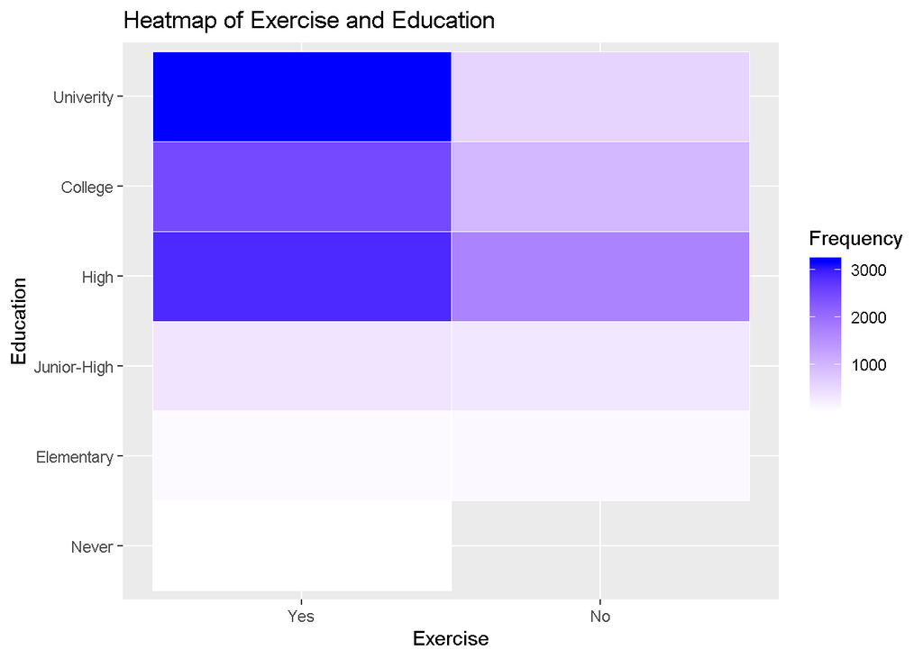

```r
# contingency table(summary) :grouped first by Exercise and then Education
summary <- oh_month %>%
  group_by(Exercise,Education) %>%
  summarise(n=n())

summary %>%
  ggplot() +
  geom_tile(aes(x=Exercise,y=Education,fill=n),
            color="white") +
  scale_fill_gradient(low="white",high="blue") +
  labs(fill = "Frequency",title="Heatmap of Exercise and Education")
```

#####(2). Generate a fluctuation diagram of the above contigency table.

[figure not shown]

```r
ggplot() +
  geom_point(aes(x=Exercise, y=Education,size=n),
             shape=1, data=summary)+labs(title="Fluctuation Diagram of Exercise and Month",size="Frequency") +
  theme_bw()
```

#####(3). Discuss what you find in (1) and (2). Contingency table and fluctuation diagram can show the same distribution of intensity between selected factors. However, Contingency table of heat map is still visually a lot easier/faster to understand to me and more appealing than the fluctuaion diagram.

#####(4). Generate a mosaic plot between “MONTH” and one of the variables you selected.

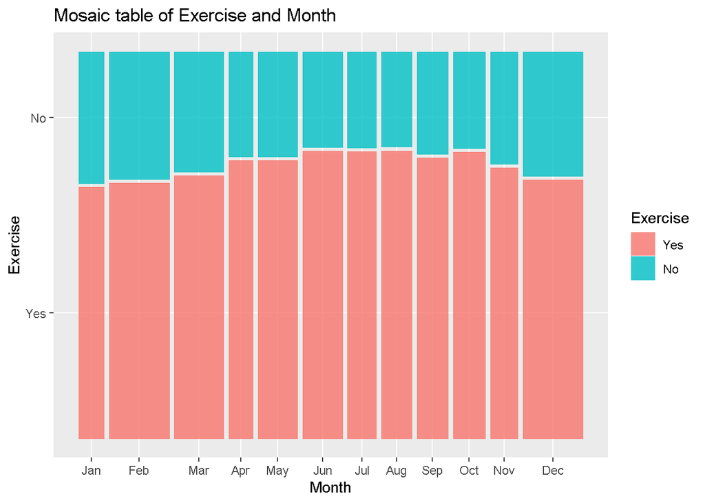

```r
library(ggmosaic)
oh_month$Month <-ordered(oh_month$Month,
                        levels=c("Jan","Feb","Mar", "Apr","May","Jun","Jul","Aug","Sep","Oct","Nov","Dec"))

ggplot() +
  geom_mosaic(aes(x=product(Month), fill=Exercise), data=oh_month)+
  labs(x="Month",y="Exercise"
,title="Mosaic table of Exercise and Month")
```

##—————————————————-##

In addition, regardless exercise part, people in higher education (Univerityersity and College graduates) takes big proportion of total population.

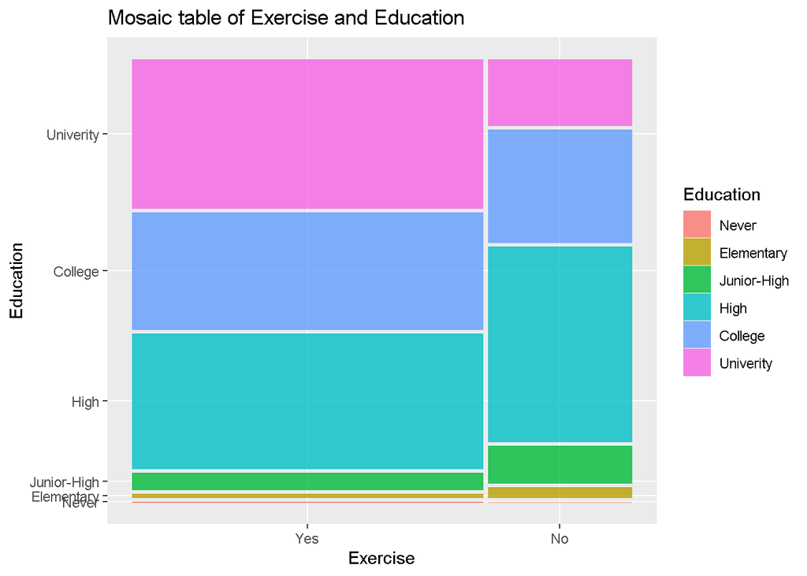

```r
ggplot() +
  geom_mosaic(aes(x=product(Exercise), fill=Education), data=oh_month)+
  labs(x="Exercise",y="Education",title="Mosaic table of Exercise and Education")
```